# Economic Data 2026 - Labs

Week 7

*Aims*: Data cleaning, applying functions by groups, libraries and data formats.

Your country depends on the timing of your lab session:

- Monday: Norway
- Tuesday: Germany
- Wednesday: Spain
- Thursday: France

## Part 1 (Wide and long datasets)

In this exercise, we will consider the distribution of GDP per capita for a range of countries in USD and USD adjusted for PPP. For this exercise, we will use data from the [World Bank Open Data](https://data.worldbank.org/).

Go to the World Bank Open Data website, search for and download data on GDP per capita in current US dollars for as many countries as possible. The data should be in Excel format.

- Open the dataset in Excel. Is the format wide or long?
- Import the data into RStudio. Assign it the name `df_gdppc`.
- Change the format of the dataset from wide to long. The following function can be helpful.

```r
df_gdppc <- reshape(
  df_gdppc,
  varying   = list(names(df_gdppc)[5:ncol(df_gdppc)]),
  v.names   = "gdppc",
  timevar   = "year",
  times     = names(df_gdppc)[5:ncol(df_gdppc)],
  idvar     = c("Country Name", "Country Code", "Indicator Name", "Indicator Code"),
  direction = "long"
)
```

- Keep only data for the year 2022 and rename the column with country information to `country`
- Download a dataset on GDP per capita in US dollars adjusted for PPP for as many countries as possible.
- Import the dataset and assign it the name `df_gdppc_ppp`. Then, follow the same steps as for `df_gdppc`.
- Plot a histogram of the logarithm of GDP per capita from `df_gdppc` and one histogram of GDP per capita from `df_gdppc_ppp`.

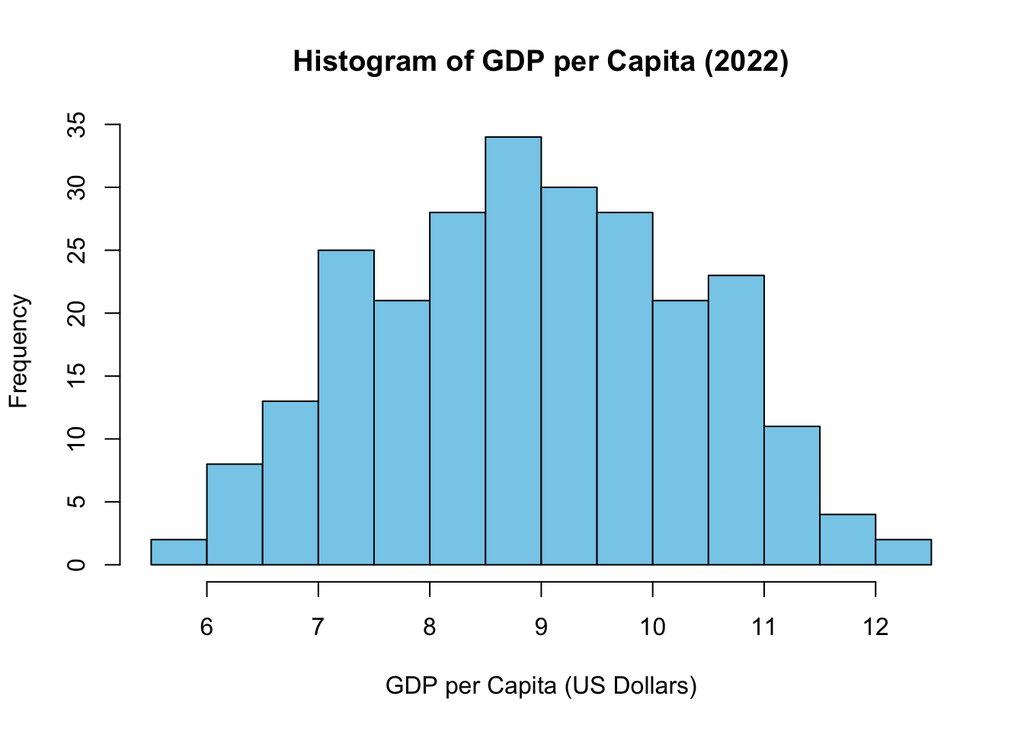

- Calculate the standard deviations of the two measures of GDP per capita. Comment on your findings in the script. **Hint**: Remember the [slides](https://sebastianellingsen.github.io/economic_data_course/lectures/lecture_4.html#24) on descriptive statistics.

## Part 2 (Data cleaning using dplyr)

In this exercise, we will calculate the rate of inflation for our assigned country. It is useful to have a look at lab_4.R which is available on Blackboard. The growth rate of the price index $P_{t}$ between month $t$ and $t-12$ is given by
$$\begin{equation}
\pi_{t} = 100\times\frac{P_{t} - P_{t-12}}{P_{t-12}}.
\end{equation}$$
The slides for this week might be useful for this exercise. You can find these [here](https://sebastianellingsen.github.io/economic_data_course/lectures/lecture_6.html#42).

**Some `dplyr` functions**

`%>%` pipe, read as “then do”.

`mutate()`: create new column or manipulate existing column.

`select()`: select columns to keep in the dataframe.

`rename()`: rename column.

`filter()`: select rows in a dataframe.

`group_by()`: perform some subsequent operation by group.

- Go to Eurostat and download data on consumer prices. In particular, download the HICP with monthly data (Index, 2015=100). Select the series *All items HICP*, *Overall index excluding energy*, *Energy*, and *Food including alcohol and tobacco*. Download the data since January 2015 until today as a .csv file.
- Load the dataset into R under the `df`.
- Import the library `dplyr` at the beginning of your script.
- Keep the columns `geo`, `TIME_PERIOD`, `OBS_VALUE`, and `coicop`. **Hint**: Use `select()` and `%>%`.
- Rename the columns to more informative names. **Hint**: Use `rename()` and `%>%`.
- Make the column containing the time variable as a date. **Hint**: Use `mutate()`, `%>%`, and the code from the previous lab.
- Group the dataset by the variable denoting the series. **Hint**: Use `group_by()`.
- Calculate the growth rate of prices by series. **Hint**: Use `mutate()`, `%>%`, and the code from the previous lab.
- Keep only observations after January 2018. **Hint**: Use `filter()` and `%>%`.
- Construct the below plot.

[figure not shown]

```r
# Define colors for the different series
colors <- c("blue", "green", "red", "purple")

# Set up the main plot area without drawing anything initially
plot(df$date[df$series == "CP00"],
     df$g_p[df$series == "CP00"],
     type = "n",
     xlab = "",
     ylab = "prices and stuff",
     xaxt = "n",
     yaxt = "n",
     main = "some title",
     ylim = c(-20, 40))

lines(df$date[df$series == "CP00"],
      df$g_p[df$series == "CP00"],
      col = colors[1],
      lwd = 1.2)

lines(df$date[df$series == "FOOD"],
      df$g_p[df$series == "FOOD"],
      col = colors[2],
      lwd = 1.2)

# Add legend at the bottom
legend("bottomright",
       legend = c('All items-HICP', 'Food', 'Energy', 'HICP ex. energy'),
       col = colors,
       lwd = 1.2,
       bty = "n",
       inset = c(0.05, 0))

# Customize x-axis with specific date labels
axis(1, at = seq(min(df$date), max(df$date), by = "6 months"),
     labels = format(seq(min(df$date), max(df$date), by = "6 months"), "%m-%Y"), las = 2, cex.axis = 0.8)

# Customize y-axis
axis(2, las = 1, cex.axis = 0.8)

# Add caption
mtext("some source", side = 1, line = 4, adj = 0, cex = 0.7)
```